# WinterMath Gilde Week1

Kyle Gilde

January 3, 2017

# Calculus & Linear Algebra

## Calculus

#### 1. It costs a toy retailer $10 to purchase a certain doll. He estimates that, if he charges x dollars per doll, he can sell 80 - 2x dolls per week. Find a function for his weekly profit.

```
(80-2*x)*(x-10);
```

```
[1] "Simplify & Pretty Form"
```

```
    /           2       \
2 * \ 50 * x - x  - 400 /
```

#### 2. Given the following function: f (x) = 8x^3 + 7x^2 - 5

- Step 1. Find f (3).

```
[1] 274
```

- Step 2. Find f (-2).

```
[1] -41
```

- Step 3. Find f (x + c).

```
8*(x+c)^3+7*(x+c)^2-5;
```

```
[1] "Simplify & Pretty Form"
```

```
     3         2            2             2
8 * x  + 24 * x  * c + 7 * x  + 24 * x * c  + 14 * x * c +

     3        2
8 * c  + 7 * c  - 5
```

#### 4. Find the derivative for the following function. f (x) = -2x^3

```
function (x)
-(6 * x^2)
```

#### 5. Find the derivative for the following function. f (x) = -8/x^2

```
function (x)
16/x^3
```

```
function (x)
1.66666666666667/x^0.666666666666667
```

#### 7. Find the derivative for the following function. y = -2x^(9/8)

```
function (x)
-(2.25 * x^0.125)
```

**-1.25**

#### 9. The cost of producing x baskets is given by C(x) = 630 + 2.4x. Determine the average cost function.

**(630 + 2.4 * x) / x**

#### 10. Use the Product Rule or Quotient Rule to find the derivative. f(x) = (-2x^(-2) + 1) (-5x + 9)

```
(4*(9-5*x))/x^3-5*(1-2/x^2);
```

```
      5         3         2
-5 * x  - 10 * x  + 36 * x
---------------------------
             5
            x
```

#### 11. Use the Product Rule or Quotient Rule to find the derivative. f(x) = (5x^(1/2) + 7)/(-x^3 + 1)

```
(2.5/Sqrt(x)+(3*x^2*(5*Sqrt(x)+7))/(1-x^3))/(1-x^3);
```

```
      3                     2           3
15 * x  + 21 * Sqrt( x ) * x  + -2.5 * x  + 2.5
-----------------------------------------------
        /  6        3     \
        \ x  - 2 * x  + 1 / * Sqrt( x )
```

#### 12. Find the derivative for the given function. Write your answer using positive and negative exponents and fractional exponents instead of radicals. f(x) = (3x^(-3) - 8x + 6)^(4/3)

```
-1.33333333333333*(3/x^3-8*x+6)^0.333333333333333*(9/x^4+8);
```

**(-4/3) * (3 * x^-3 - 8 * x + 6)^(1/3) * (9 * x^-4+8)**

```
[1] 547
```

#### 14. The average home attendance per week at a Class AA baseball park varied according to the formula N(t) = 1000(6 + 0.1t)^(1/2) where t is the number of weeks into the season (0 <= t <= 14) and N represents the number of people.

- Step 1. What was the attendance during the third week into the season? Round your answer to the nearest whole number.

```
[1] 2510
```

- Step 2. Determine
  $$N´(5)$$
  and interpret its meaning. Round your answer to the nearest whole number.

```
[1] 20
```

**The attendance is increasing at a rate of 20 people during week 5.**

#### 15. Consider the following function: 3x^3 + 4y^3 = 77

- Step 1. Use implicit differentiation to find dy/dx.

```
function(x, y) -3 * x^2 / 4 * y^2
```

- Step 2. Find the slope of the tangent line at (3,-1).

```
[1] -6.75
```

#### 16. Find the intervals on which the following function is increasing and on which it is decreasing. f(x) = (x + 3)/(x - 8)

**never increasing; decreasing on on (-Inf, 8) and (8, Inf)**

#### 17. A frozen pizza is placed in the oven at t = 0. The function F(t) = 14 + (367t<sup>2)/(t</sup>2 + 100) approximates the temperature (in degrees Fahrenheit) of the pizza at time t.

- Step 1. Determine the interval for which the temperature is increasing and the interval for which it is decreasing. Please express your answers as open intervals.

**never decreasing; increasing on (0, Inf)**

- Step 2. Over time, what temperature is the pizza approaching?

```
[1] 381
```

#### 18. A study says that the package flow in the East during the month of November follows f (x) = x^3/3340000 - (7x^2)/9475 + 42417727x/1265860000 + 1/33, where 1 <= x <= 30 is the day of the month and f (x) is in millions of packages. What is the maximum number of packages delivered in November? On which day are the most packages delivered? Round your final answer to the nearest hundredth.

```
0.41 Million Packages
```

```
November 23
```

#### 19. Use the Second Derivative Test to find all local extrema, if the test applies. Otherwise, use the First Derivative Test. Write any local extrema as an ordered pair. f(x) = 7x^2 + 28x - 35

```
[1] "Local Min:"
[1]  -2 -63
```

#### 20. Use the Second Derivative Test to find all local extrema, if the test applies. Otherwise, use the First Derivative Test. Write any local extrema as an ordered pair. f(x) = -6x^3 + 27x^2 + 180x

```
[1] "Local Min:"
[1]   -2 -204
[1] "Local Max:"
[1]   5 825
```

#### 21. A beauty supply store expects to sell 120 flat irons during the next year. It costs $1.60 to store one flat iron for one year. To reorder, there is a fixed cost of $6 , plus $4.50 for each flat iron ordered. In what lot size and how many times per year should an order be placed to minimize inventory costs?

```
function(orders_per_year) {
    120/orders_per_year * 1.6   + orders_per_year * (6 + 4.5 * 120/orders_per_year)
}
```

```
6  orders of  20 each
```

#### 22. A shipping company must design a closed rectangular shipping crate with a square base. The volume is 18432 ft^3. The material for the top and sides costs $3 per square foot and the material for the bottom costs $5 per square foot. Find the dimensions of the crate that will minimize the total cost of material.

```
function (h, L)
c(h = 6, L = 221184/L^3)
```

```
function (h, L)
c(h = 294912/h^3, L = 6)
```

```
[1] 32 24 24
```

#### 23. A farmer wants to build a rectangular pen and then divide it with two interior fences. The total area inside of the pen will be 1056 square yards. The exterior fencing costs $14.40 per yard and the interior fencing costs $12.00 per yard . Find the dimensions of the pen that will minimize the cost.

```
[1] 24
```

```
[1] 44
```

#### 24. It is determined that the value of a piece of machinery declines exponentially. A machine that was purchased 7 years ago for $67000 is worth $37000 today. What will be the value of the machine 9 years from now? Round your answer to the nearest cent.

```
[1] 17244.5
```

#### 25. The demand function for a television is given by p = D(x) = 23.2 - 0.4x dollars. Find the level of production for which the revenue is maximized.

```
[1] 29
```

#### 26. The amount of goods and services that costs $400 on January 1, 1995 costs $426.80 on January 1, 2006 . Estimate the cost of the same goods and services on January 1, 2017. Assume the cost is growing exponentially. Round your answer to the nearest cent.

```
[1] 455.4
```

#### 27. A manufacturer has determined that the marginal profit from the production and sale of x clock radios is approximately 380 - 4x dollars per clock radio.

- Step 1. Find the profit function if the profit from the production and sale of 38 clock radios is $1700.

```
function(x) -9852 + 380 * x - 2 * x^2
```

- Step 2. What is the profit from the sale of 56 clock radios?

```
[1] 5156
```

-1.25*(ln(y))^4 + C

#### 29. It was discovered that after t years a certain population of wild animals will increase at a rate of P’(t) = 75 - 9t^(1/2) animals per year. Find the increase in the population during the first 9 years after the rate was discovered. Round your answer to the nearest whole animal.

```
[1] 513
```

#### 30. Find the area of the region bounded by the graphs of the given equations. y = 6x^2,y = 6 * x^.5 Enter your answer below.

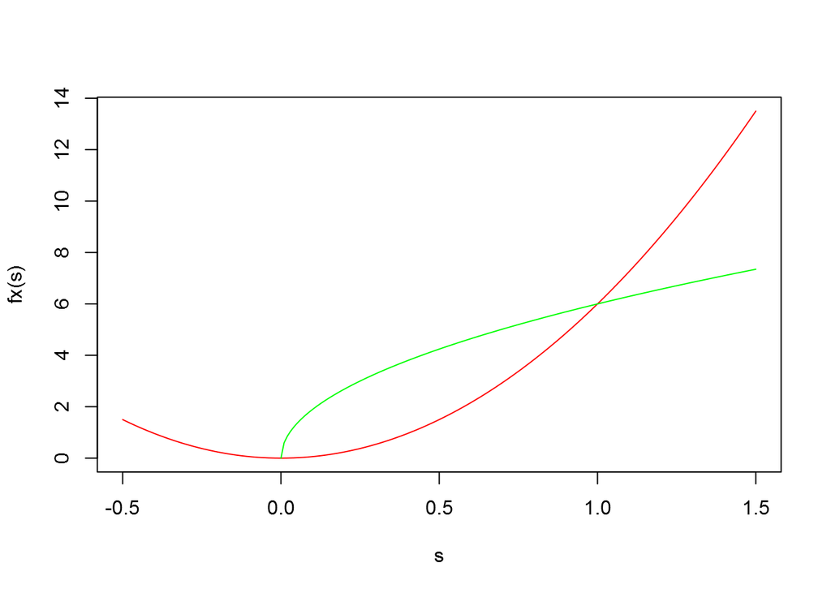

```
[1] 2
```

#### 31. Solve the differential equation given below. dy/dx = x^3 * y

**y = exp(x^4/4) + C**

```
[1] "-144/5"
```

#### 33. The following can be answered by finding the sum of a finite or infinite geometric sequence. Round the solution to 2 decimal places. A rubber ball is dropped from a height of 46 meters, and on each bounce it rebounds up 22 % of its previous height.

- Step 1. How far has it traveled vertically at the moment when it hits the ground for the 20^th time?

```
[1] 71.95
```

- Step 2. If we assume it bounces indefinitely, what is the total vertical distance traveled?

```
[1] 71.95
```

#### 34. Find the Taylor polynomial of degree 5 near x = 4 for the following function. y = 3e^(5x - 3)

**3e^17 + 15e^17 (x-4) + 75/2 e^17 (x-4)^2 + 125/2 e^17 (x-4)^3 + 625/8 e^17 (x-4)^4 + 625/8 e^17 (x-4)^5**

## Linear Algebra

#### 1. Using matrix operations, describe the solutions for the following family of equations:

x + 2y - 3z = 5

2x + y - 3z = 13

-x + y + 2z= -8

- 1. Find the inverse of the above 3x3 (non-augmented) matrix.

```
           [,1]      [,2] [,3]
[1,] -0.8333333 1.1666667  0.5
[2,]  0.1666667 0.1666667  0.5
[3,] -0.5000000 0.5000000  0.5
```

- 2. Solve for the solution using R.

```
[1]  7 -1  0
```

- 3. Modify the 3x3 matrix such that there exists only one non-zero variable in the solution set.

```
     [,1] [,2] [,3]
[1,]    1    5   -3
[2,]    2   13   -3
[3,]   -1   -8    2
```

```
[1] 0 1 0
```

#### 2. Consider the matrix, q=matrix(c(3,1,4,4,3,3,2,3,2),nrow=3). Let b=c(1,4,5). Use Cramer’s rule and R to determine the solution, x, to qx=b, if one exists. Show all determinants.

```
[1]  13  19 -33  44
```

```
[1]  1.461538 -2.538462  3.384615
```